DS 6030 | Fall 2024 | University of Virginia

# Homework #1: Supervised Learning

Author

**SOLUTIONS**

Published

Fall 2024

**Warning**

These solutions are only for the private use of the students of DS 6030 Fall 2024. Sharing of the solutions, posting on the internet, selling to a company, or possession by anyone outside of the class constitutes a violation of the honor policy.

# Required R packages and Directories

```r
library(tidyverse) # functions for data manipulation
```

# Problem 1: Evaluating a Regression Model

## a. Data generating functions

Create a set of functions to generate data from the following distributions:

$$\begin{align*}
X &\sim \mathcal{N}(0, 1) \\
Y &= -1 + .5X + .2X^2 + \epsilon \\
\epsilon &\sim \mathcal{N}(0,\, \sigma)
\end{align*}$$

**Solution**

```r
sim_x <- function(n) rnorm(n)           # N[mu=0, sigma=1]
f <- function(x) -1 + .5*x + .2*x^2     # true mean function
sim_y <- function(x, sd){               # generate Y|X from N{f(x),sd}
  n = length(x)
  f(x) + rnorm(n, sd=sd)
}
```

## b. Generate training data

Simulate $n=100$ realizations from these distributions using $\sigma=3$. Produce a scatterplot and draw the true regression line $f(x) = E[Y \mid X=x]$.

- Use `set.seed(611)` prior to generating the data.

**Solution**

```r
#-- Settings
n = 100       # number of observations
sd = 3        # set the standard deviation

#-- Generate Data
set.seed(611)
x = sim_x(n)
y = sim_y(x, sd = sd)
```

**ggplot2**

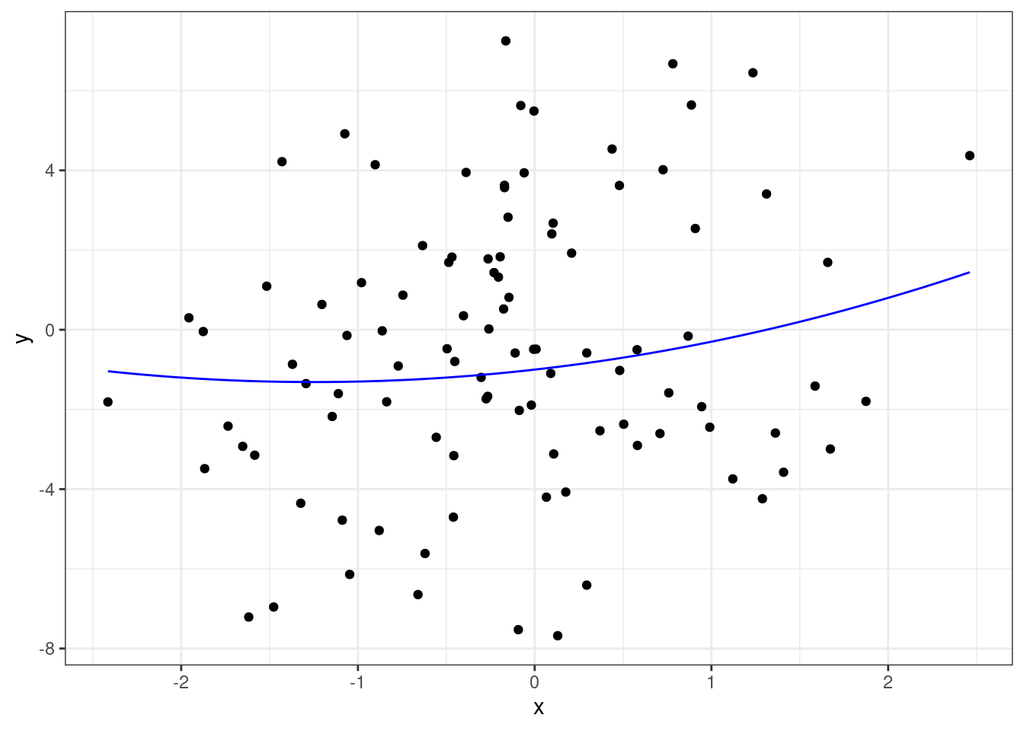

```r
#-- Scatterplot: Tidyverse
ggplot(tibble(x,y), aes(x,y)) +
  geom_point() +
  geom_function(fun=f, color="blue")
```

**Base R**

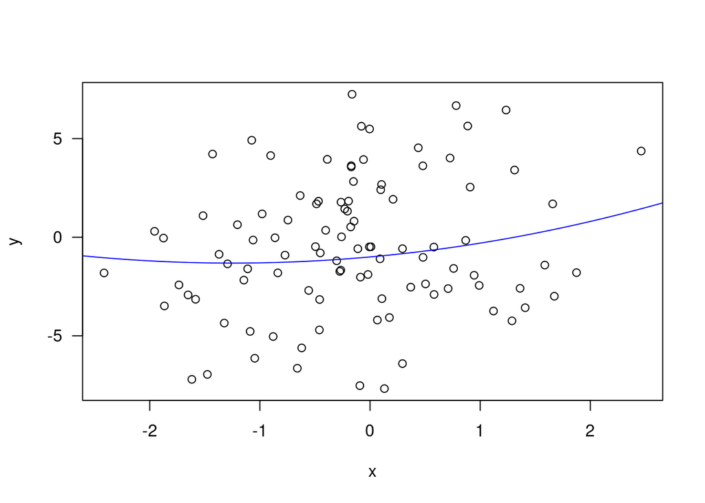

```r
#-- Scatterplot: Base R
plot(x, y, las=1)
curve(f, from=-3, to=3, add=TRUE, col="blue")
```

## c. Fit three models

Fit three polynomial regression models using least squares: linear, quadratic, and cubic. Produce another scatterplot, add the fitted lines and true population line $f(x)$ using different colors, and add a legend that maps the line color to a model.

- Note: The true model is quadratic, but we are also fitting linear (less complex) and cubic (more complex) models.

**Solution**

```r
#: Fit Models
fit1 = lm(y~x)           # linear
fit2 = lm(y~poly(x,2))   # quadratic
fit3 = lm(y~poly(x,3))   # cubic
```

```r
#: Make Estimates over range of x values
xseq = seq(-3, 3, length=200)
yhat1 = predict(fit1, tibble(x=xseq))
yhat2 = predict(fit2, tibble(x=xseq))
yhat3 = predict(fit3, tibble(x=xseq))
```

**ggplot2**

```r
#: make data for plotting; convert to long format
pred.data = tibble(
  x = xseq,
  linear = yhat1,
  quadratic = yhat2,
  cubic = yhat3,
  true = f(xseq)
  ) %>%
  pivot_longer(
    cols=-x,
    names_to="model",
    values_to="y"
  )
```

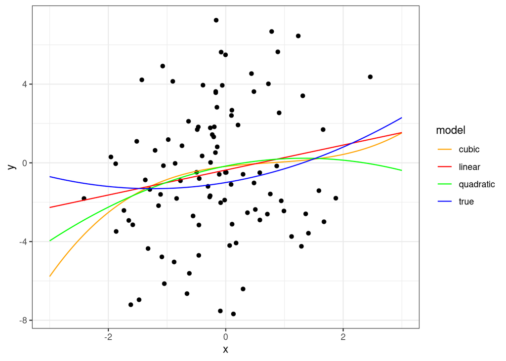

```r
#: plot
ggplot(tibble(x,y), aes(x,y)) +
  geom_point() +
  geom_line(data=pred.data, aes(color=model)) +
  scale_color_manual(values=c(true = "blue", linear="red", quadratic="green", cubic="orange"))
```

**Base R**

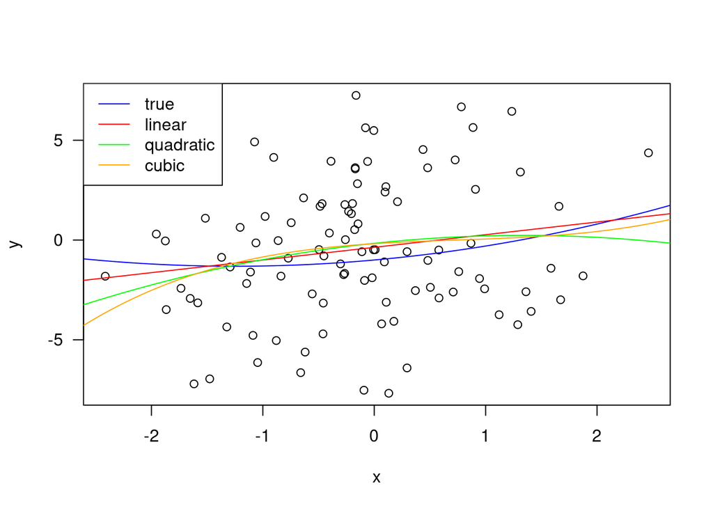

```r
#- base R
plot(x, y, las=1)
curve(f, from=-3, to=3, add=TRUE, col="blue")
lines(xseq, yhat1, col="red")
lines(xseq, yhat2, col="green")
lines(xseq, yhat3, col="orange")
legend("topleft", c("true", "linear", "quadratic", "cubic"),
       col=c("blue", "red", "green", "orange"), lty=1)
```

**Tidy (+)**

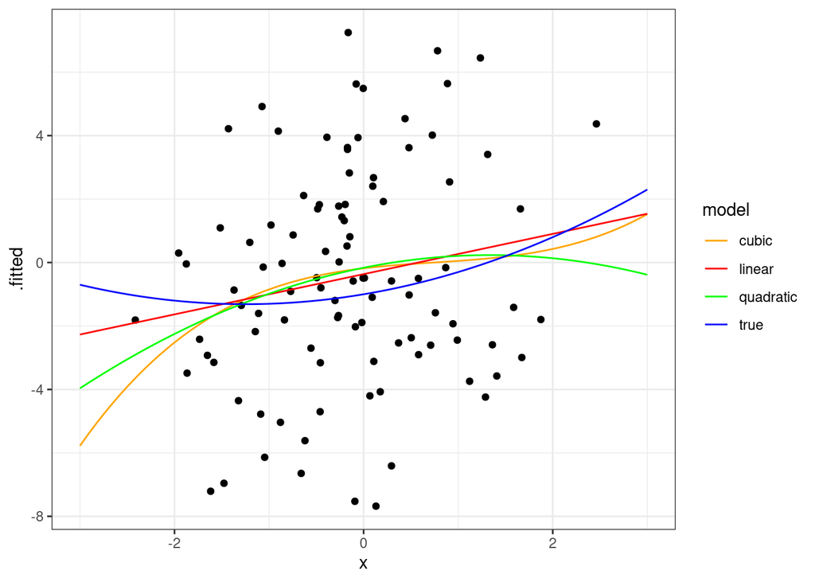

```r
library(purrr)
library(broom)

#: fit all models, save as list
degrees = c(linear = 1, quadratic = 2, cubic = 3)
fits = purrr::map(degrees, ~lm(y~poly(x, degree=.)))

#: add predictions using broom::augment, save as tibble
pred_data = map_dfr(fits, ~broom::augment(., newdata = tibble(x=xseq)),
        .id = "model") %>%
  # add true mean
  bind_rows(
    tibble(x = xseq, model = "true", .fitted = f(x))
  )

#: plot
pred_data %>%
  ggplot(aes(x, .fitted, color=model)) +
  annotate("point", x=x, y=y) +
  geom_line() +
  scale_color_manual(values=c(true = "blue", linear="red", quadratic="green", cubic="orange"))
```

Notice that while the true regression function is convex, the estimated quadratic is concave. This will have implications on its performance (see below).

## d. Predictive performance

Generate a *test data* set of 10,000 observations from the same distributions. Use `set.seed(612)` prior to generating the test data.

- Calculate the estimated mean squared error (MSE) for each model.
- Are the results as expected?

**Solution**

```r
#: Generate Test Data
ntest = 10000                           # Number of test samples
set.seed(612)                           # set *different* seed
xtest = sim_x(ntest)                    # generate test X's
ytest = sim_y(xtest, sd=sd)             # generate test Y's
```

```r
#: Make Predictions on Test Data
yhat1 = predict(fit1, tibble(x=xtest))
yhat2 = predict(fit2, tibble(x=xtest))
yhat3 = predict(fit3, tibble(x=xtest))
```

Estimate Risk (using squared error loss)

**tidyverse (using columns)**

```r
#- MSE with tidyverse (using columns)
tibble(x=xtest, y=ytest, linear=yhat1, quadratic=yhat2, cubic=yhat3) %>%
  summarize(across(c(-x, -y), ~mean((y - .)^2)))
```

```
# A tibble: 1 × 3
  linear quadratic cubic
   <dbl>     <dbl> <dbl>
1   9.29      9.58  9.65
```

**tidyverse (using groups)**

```r
#- MSE with tidyverse (using groups)
tibble(x=xtest, y=ytest, linear=yhat1, quadratic=yhat2, cubic=yhat3) %>%
  pivot_longer(cols=c(-x, -y), names_to="model", values_to="yhat") %>% # make long
  mutate(model = factor(model, levels=c('linear', 'quadratic', 'cubic'))) %>% # printing order
  mutate(sq.error = (y-yhat)^2) %>%           # add squared error
  group_by(model) %>% summarize(Risk=mean(sq.error)) # mean squared error
```

```
# A tibble: 3 × 2
  model      Risk
  <fct>     <dbl>
1 linear     9.29
2 quadratic  9.58
3 cubic      9.65
```

**tidy (+)**

```r
fits %>%
  # predictions from all models, list of predictions
  map(~broom::augment(., newdata = tibble(x=xtest, y=ytest))) %>%
  # evaluate and convert to dataframe/tibble
  map_df(~mean(.$.resid^2))
```

```
# A tibble: 1 × 3
  linear quadratic cubic
   <dbl>     <dbl> <dbl>
1   9.29      9.58  9.65
```

**Base R**

```r
#- MSE with base R
R1 = mean((ytest - yhat1)^2)
R2 = mean((ytest - yhat2)^2)
R3 = mean((ytest - yhat3)^2)
c(linear=R1, quadratic=R2, cubic=R3)
```

```
   linear quadratic     cubic
     9.29      9.58      9.65
```

The true regression function is quadratic, so if we could obtain sufficient estimates of the parameters, the quadratic model would be superior. However, in this case the parameters are not estimated well enough and we find the simpler model predicts better. Notice in the plot given in the previous section that the estimated quadratic function curves the wrong way, giving the poor fit.

But how likely was this result? Can we often expect the simpler model to perform better than the true model? We explore this in the subsequent problems.

## e. Optimal performance

What is the best achievable MSE? That is, what is the MSE if the true $f(x)$ was used to evaluate the test set? How close does the best method come to achieving the optimum?

**Solution**

The best achievable MSE is the *irreducible error* $\int_x V(Y \mid X=x) \Pr(dx) = \int_x \sigma^2 \Pr(dx) = \sigma^2 \int_x \Pr(dx) = \sigma^2 = 9$.

Notice that this is an expected value. With `ntest=10000`, we should get an estimate very close to the true value

```r
yopt = sim_y(xtest, sd=0) # or: f(xtest)        # optimal estimate (under squared loss)
mean((ytest-yopt)^2)   # estimated optimal MSE
```

```
[1] 8.97
```

Either answer by theoretical arguments or from finite test set are correct.

## f. Replication

The MSE scores obtained in part *d* came from one realization of training data. Here will we explore how much variation there is in the MSE scores by replicating the simulation many times.

- Re-run parts b. and c. (i.e., generate training data and fit models) 100 times.
  - Do not generate new testing data
  - Use `set.seed(613)` prior to running the simulation and do not set the seed in any other places.
- Calculate the test MSE for all simulations.
  - Use the same test data from part d. (This question is only about the variability that comes from the *training data*).
- Create kernel density or histogram plots of the resulting MSE values for each model.

**Solution**

```r
#: simulation settings
sd = 3
n = 100
niters = 100
set.seed(613)
```

**Loop**

```r
out = vector("list", niters)        # initialize results object
for(i in 1:niters){

  #: Generate Training Data
  x = sim_x(n)
  y = sim_y(x, sd=sd)

  #: Fit Models
  fit1 = lm(y~x)                          # linear
  fit2 = lm(y~poly(x,2))                  # quadratic
  fit3 = lm(y~poly(x,3))                  # cubic

  #: Make Predictions on Test Data
  yhat1 = predict(fit1, tibble(x=xtest))
  yhat2 = predict(fit2, tibble(x=xtest))
  yhat3 = predict(fit3, tibble(x=xtest))

  #: Score/Evaluate Models
  score = tibble(x=xtest, y=ytest, linear=yhat1, quadratic=yhat2, cubic=yhat3) %>%
    summarize(across(c(-x, -y), ~mean((y - .)^2)))

  #: Save scores
  out[[i]] = score
}

#: convert to data frame
results = bind_rows(out, .id = "iter")
```

**map**

```r
fit_and_score <- function(xtest, ytest){

  #: Generate Training Data
  x = sim_x(n)
  y = sim_y(x, sd=sd)

  #: Fit Models
  fit1 = lm(y~x)                          # linear
  fit2 = lm(y~poly(x,2))                  # quadratic
  fit3 = lm(y~poly(x,3))                  # cubic

  #: Make Predictions on Test Data
  yhat1 = predict(fit1, tibble(x=xtest))
  yhat2 = predict(fit2, tibble(x=xtest))
  yhat3 = predict(fit3, tibble(x=xtest))

  #: Score/Evaluate Models
  score = tibble(x=xtest, y=ytest, linear=yhat1, quadratic=yhat2, cubic=yhat3) %>%
    summarize(across(c(-x, -y), ~mean((y - .)^2)))
  return(score)
}
```

```r
set.seed(613)
results = map(1:niters, ~fit_and_score(xtest, ytest)) %>%
  bind_rows(.id = "iter")
```

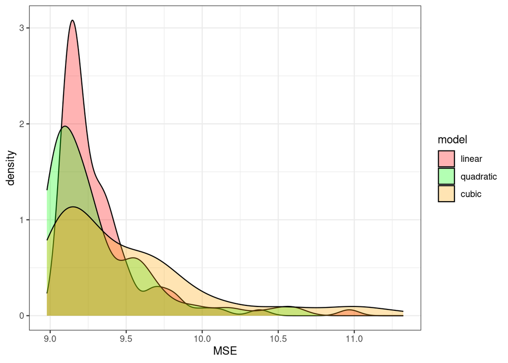

```r
#: convert to long format for plotting; use factors to control plotting order
results_long = results %>%
  pivot_longer(-iter, names_to = "model", values_to = "MSE") %>%
  mutate(model = factor(model, levels=c("linear", "quadratic", "cubic")))

#: density of MSE values
ggplot(results_long, aes(MSE)) +
  geom_density(aes(fill=model), alpha=.3) +
  scale_fill_manual(values=c(linear="red", quadratic="green",
                             cubic="orange"))
```

## g. Best model

Show a count of how many times each model was the best. That is, out of the 100 simulations, count how many times each model had the lowest MSE.

**Solution**

```r
results_long %>%
  group_by(iter) %>%
    slice_min(MSE) %>%
  ungroup() %>%
  count(model) %>%
  mutate(p = n/sum(n))
```

```
# A tibble: 3 × 3
  model         n     p
  <fct>     <int> <dbl>
1 linear       28  0.28
2 quadratic    65  0.65
3 cubic         7  0.07
```

In this case, the (true) quadratic model gave the best MSE 65% of the time.

## h. Function to implement simulation

Write a function that implements the simulation in part *f*. The function should have arguments for i) the size of the training data $n$, ii) the standard deviation of the random error $\sigma$, and iii) the test data. Use the same `set.seed(613)`.

**Solution**

```r
run_sim <- function(n, sd, data_test = tibble(x=xtest, y=ytest),
                    seed = 613, niters = 100){
  if(!is.null(seed)) set.seed(seed)

  out = vector("list", niters)        # initialize results object
  for(i in 1:niters){

    #: Generate Training Data
    x = sim_x(n)
    y = sim_y(x, sd=sd)

    #: Fit Models
    fit1 = lm(y~x)                          # linear
    fit2 = lm(y~poly(x,2))                  # quadratic
    fit3 = lm(y~poly(x,3))                  # cubic

    #: Make Predictions on Test Data
    yhat1 = predict(fit1, data_test)
    yhat2 = predict(fit2, data_test)
    yhat3 = predict(fit3, data_test)

    #: Score/Evaluate Models
    score = data_test %>%
      mutate(linear=yhat1, quadratic=yhat2, cubic=yhat3) %>%
      summarize(across(c(-x, -y), ~mean((y - .)^2)))

    #: Save results
    out[[i]] = score
  }

  #: convert to data frame
  results = bind_rows(out, .id = "iter")
return(results)
}
```

## i. Performance when $\sigma=2$

Use your function to repeat the simulation in part *f*, but use $\sigma=2$. Report the number of times each model was best (you do not need to produce any plots).

- Be sure to generate new test data with ($n = 10000$, $\sigma = 2$, using `seed = 612`).

**Solution**

Generate the test data with $\sigma = 2$.

```r
#: Generate Test Data
ntest = 10000                           # Number of test samples
set.seed(612)                           # set *different* seed
xtest = sim_x(ntest)                    # generate test X's
ytest = sim_y(xtest, sd=2)              # generate test Y's
data_test = tibble(x = xtest, y = ytest)# make into tibble/data frame
```

Now run the simulation with $\sigma=2$ and $n=100$

```r
results_i = run_sim(n=100, sd=2, data_test = data_test, seed=613)
```

```r
best_i = results_i %>%
  # convert to long format
  pivot_longer(-iter, names_to = "model", values_to = "MSE") %>%
  # set factor levels to control order
  mutate(model = factor(model, levels=c("linear", "quadratic", "cubic"))) %>%
  # choose row/model with minimum MSE
  group_by(iter) %>%
    slice_min(MSE) %>%
  ungroup() %>%
  # counts
  count(model) %>% mutate(p = n/sum(n))

best_i
```

```
# A tibble: 3 × 3
  model         n     p
  <fct>     <int> <dbl>
1 linear       19  0.19
2 quadratic    71  0.71
3 cubic        10  0.1
```

```r
#: plot
# ggplot(results_i, aes(Risk)) +
#   geom_density(aes(fill=model), alpha=.3) +
#  scale_fill_manual(values=c(linear="red", quadratic="green", cubic="orange"))
```

As the variance decreases, we see the (true) quadratic model now gives the best performance 71% of the time. The too simple linear model doesn’t predict as well as before but the cubic model now predicts better.

## j. Performance when $\sigma=4$ and $n=300$

Repeat *i*, but now use $\sigma=4$ and $n=300$.

- Be sure to generate new test data with ($n = 10000$, $\sigma = 4$, using `seed = 612`).

**Solution**

Generate the test data with $\sigma = 4$.

```r
#: Generate Test Data
ntest = 10000                           # Number of test samples
set.seed(612)                           # set *different* seed
xtest = sim_x(ntest)                    # generate test X's
ytest = sim_y(xtest, sd=4)              # generate test Y's
data_test = tibble(x = xtest, y = ytest)# make into tibble/data frame
```

```r
results_j = run_sim(n=300, sd=4, data_test = data_test, seed=613)
```

```r
best_j = results_j %>%
  # convert to long format
  pivot_longer(-iter, names_to = "model", values_to = "MSE") %>%
  # set factor levels to control order
  mutate(model = factor(model, levels=c("linear", "quadratic", "cubic"))) %>%
  # choose row/model with minimum MSE
  group_by(iter) %>%
    slice_min(MSE) %>%
  ungroup() %>%
  # counts
  count(model) %>% mutate(p = n/sum(n))

best_j
```

```
# A tibble: 3 × 3
  model         n     p
  <fct>     <int> <dbl>
1 linear        8  0.08
2 quadratic    80  0.8
3 cubic        12  0.12
```

```r
#: plot
# ggplot(results_j, aes(Risk)) +
#   geom_density(aes(fill=model), alpha=.3) +
#  scale_fill_manual(values=c(linear="red", quadratic="green", cubic="orange"))
```

We see that increasing sample size also allows the true model to come out best more often.

## k. Understanding

Describe the effects $\sigma$ and $n$ has on selection of the best model? Why is the *true* model form (i.e., quadratic) not always the *best* model to use when prediction is the goal?

**Solution**

It may be helpful to think of this as a signal vs. noise problem. When the sample size grows or the variance shrinks, the signal is easier to discern and the (true) quadratic model is more likely to give the best performance.

Another perspective is to consider parameter estimation (and the variation in the estimated parameters). When the sample size grows or the variance shrinks, the estimated parameters have less variance and it is less likely a *wild* fit will result from the more complex model.

The cubic model was occasionally the best model. This is not too surprising as in the limit (as either $n$ increases or $\sigma$ decreases), the cubic model will reduce to the (nested) quadratic model by estimating $\beta_3 \approx 0$. When $\beta_3$ is estimated close to $0$, then the cubic model should give very similar performance to the quadratic.